# MachineLearningProject

NEO

12/13/2019

## Executive Summary

This is the project for week four of the Machine Learning class that is part of Coursera’s Data Science suite. This project will follow steps for machine learning:

1.Define Problem. 2.Load Data, Sumamrize and Prepare Data. 3.Visualizing the dataset. 4.Evaluate Algorithms. 5.Making some predictions. 6.Improve Results. 7.Present Results.

## Background

The Human Activity Recognition (HAR) data used in this project and more information is available from: http://web.archive.org/web/20161224072740/http:/groupware.les.inf.puc-rio.br/har. Participantds were asked to perform barbell lifts correctly and incorrectly in 5 different ways. Data from accelerometers on the belt, forearm, arm, and dumbell of 6 participants and predict the manner in which persons did the exercise.

The libraries included in this project are listed here in the librarySetUp section of R code.

```r
       library(dplyr)
       library(data.table)
       library(caret)
       library(rpart);
       library(ggplot2)
       library(randomForest);
       library(R.utils)
```

The code for setting up the local analysis directory, retieving data file and reading in the dataset described and documented below. First, a data directory in the users working directory is created if it does not exist.

```r
       if(!file.exists('./data')) dir.create('./data')
```

Data for the analysis is retrieved using R script. The code for this is included in the report below for purposes of reproduction of this analyisis.

```r
#
      if(!file.exists('./data/pml-testing.csv')) {
       fileURL<-'https://d396qusza40orc.cloudfront.net/predmachlearn/pml-testing.csv'
       download.file(fileURL, destFile = './data/pml-testing.csv')
      }
      if(!file.exists('./data/pml-training.csv')) {
       fileURL<-'https://d396qusza40orc.cloudfront.net/predmachlearn/pml-testing.csv'
       download.file(fileURL, destFile = './data/pml-training.csv')
      }
```

#Step 1. Load the data

```r
       fileName = './data/pml-training.csv'
       pmlTrnData <- read.csv(fileName, na.strings = c("NA", ""), strip.white = TRUE,
                             stringsAsFactors=FALSE)
# Uncomment the STR function to get a look at the data.
##       str(pmlTrnData)
#
       fileName = './data/pml-testing.csv'
       pmlTstData <- read.csv(fileName, na.strings = c("NA", ""), strip.white = TRUE,
                             stringsAsFactors=FALSE)
```

#Step 2. Preprocess the Data and Create Training and Validation Data Sets Clean the data and remove data columns that have no data. This will remove all attributes containing NA: Next, on both the training and the testing data, removal of first 7 of the 60 data frame attributes since they are not pertainent attributes or predictors.

```r
       pmlTraining <- pmlTrnData[ , colSums(is.na(pmlTrnData))==0]
       pmlTesting  <- pmlTstData[ , colSums(is.na(pmlTstData))==0]

       pmlTrn <- pmlTraining[ , -c(1:7)]
       pmlTst <- pmlTesting[ , -c(1:7)]
# Show the dimension of the data set
       dim(pmlTrn)
```

```
## [1] 19622    53
```

```r
       dim(pmlTst)
```

```
## [1] 20 53
```

```r
# Create Normalize Function and apply to training and testing set
#       normalize <- function(x) {
#              num <- x - min(x)
#              denom <- max(x) - min(x)
#              return (num/denom)
#       }
#
# Normalize the data (minus the classe/problem_id)
#       tstNorm<-as.data.frame(lapply(pmlTst[1:52], normalize))
#       trnNorm<-as.data.frame(lapply(pmlTrn[1:52], normalize))
# Add problem_id/classe back to normalized data
#       tstNorm$problem_id <- pmlTst$problem_id
#           trnNorm$classe <- pmlTrn$classe
# Get understanding of the classe variable in the training data set
           levels (as.factor(pmlTrn$classe))
```

```
## [1] "A" "B" "C" "D" "E"
```

```r
# Split trnNorm into training and Validation at a 70%/30% rate
          inTrain <- createDataPartition(pmlTrn$classe, p = 0.7, list = FALSE)
         training <- pmlTrn[inTrain, ]
       validation <- pmlTrn[-inTrain, ]
```

# Step 3. Visualize the data

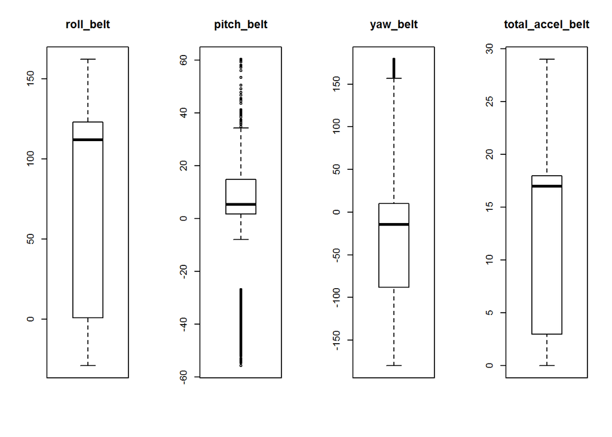

```r
# For this paper- ontly the first 4 attributes are plotted
         x <- training[,1:4]
         y <-training[,53]
         par(mfrow=c(1,4))
         for(i in 1:4) { boxplot(x[,i], main=names(training)[i])
         }
```

The dim function on the training data shows 52 attributes along with “classe” (53 col total) with 19622 rows, and the testing data has 52 similar attributes along with “problem_id” (53 col total) and 20 rows. The unique function shows that the classe variable has values: “A” “B” “C” “D” “E”.

#Step 4. Build Model Trees

```r
# Set random seed for reproducibility
       set.seed(1234)
# Assign trainControl attributes to limit the number used in the classification. I will use 5-fold repeated crossvalidation to estimate accuracy.
       ctrl<- trainControl(method="cv",number=10)
       modFitTree <- train(classe ~ ., data=training, method="rpart", trControl=ctrl)
       modFitTree
```

```
## CART
##
## 13737 samples
##    52 predictor
##     5 classes: 'A', 'B', 'C', 'D', 'E'
##
## No pre-processing
## Resampling: Cross-Validated (10 fold)
## Summary of sample sizes: 12363, 12364, 12362, 12364, 12363, 12363, ...
## Resampling results across tuning parameters:
##
##   cp          Accuracy   Kappa
##   0.03946699  0.5059331  0.35487849
##   0.06079409  0.4423861  0.25219495
##   0.11494253  0.3218296  0.05720017
##
## Accuracy was used to select the optimal model using the largest value.
## The final value used for the model was cp = 0.03946699.
```

```r
       print(modFitTree$finalModel)
```

```
## n= 13737
##
## node), split, n, loss, yval, (yprob)
##       * denotes terminal node
##
##  1) root 13737 9831 A (0.28 0.19 0.17 0.16 0.18)
##    2) roll_belt< 130.5 12593 8694 A (0.31 0.21 0.19 0.18 0.11)
##      4) pitch_forearm< -33.15 1108   12 A (0.99 0.011 0 0 0) *
##      5) pitch_forearm>=-33.15 11485 8682 A (0.24 0.23 0.21 0.2 0.12)
##       10) magnet_dumbbell_y< 439.5 9747 6989 A (0.28 0.18 0.24 0.19 0.11)
##         20) roll_forearm< 122.5 6023 3547 A (0.41 0.18 0.18 0.17 0.061) *
##         21) roll_forearm>=122.5 3724 2494 C (0.076 0.18 0.33 0.23 0.18) *
##       11) magnet_dumbbell_y>=439.5 1738  848 B (0.026 0.51 0.045 0.22 0.2) *
##    3) roll_belt>=130.5 1144    7 E (0.0061 0 0 0 0.99) *
```

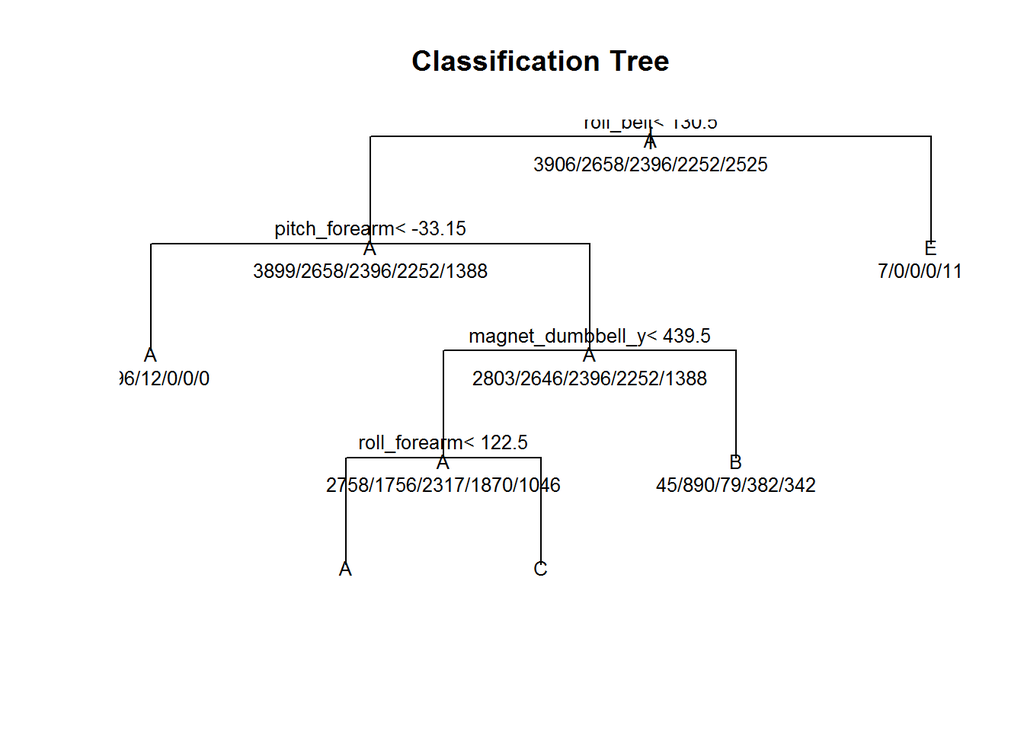

```r
# Plot Resulting Tree
       plot(modFitTree$finalModel, uniform=TRUE, main="Classification Tree")
       text(modFitTree$finalModel, use.n=TRUE, all=TRUE, cex=.8)
```

```r
# Now predict using modelFitTrees using the validation Data
       ans <- predict(modFitTree,newdata=validation)

           summary(ans)
```

```
##    A    B    C    D    E
## 3070  791 1523    0  501
```

```r
#  Result from confusionMatrix
       classe<-as.factor(validation$classe)
       confTree <- confusionMatrix(classe,ans)
       confTree
```

```
## Confusion Matrix and Statistics
##
##           Reference
## Prediction    A    B    C    D    E
##          A 1508   36  123    0    7
##          B  473  396  270    0    0
##          C  499   29  498    0    0
##          D  433  186  345    0    0
##          E  157  144  287    0  494
##
## Overall Statistics
##
##                Accuracy : 0.4921
##                  95% CI : (0.4792, 0.505)
##     No Information Rate : 0.5217
##     P-Value [Acc > NIR] : 1
##
##                   Kappa : 0.3359
##
##  Mcnemar's Test P-Value : NA
##
## Statistics by Class:
##
##                      Class: A Class: B Class: C Class: D Class: E
## Sensitivity            0.4912  0.50063  0.32699       NA  0.98603
## Specificity            0.9410  0.85414  0.87895   0.8362  0.89079
## Pos Pred Value         0.9008  0.34767  0.48538       NA  0.45656
## Neg Pred Value         0.6291  0.91677  0.78905       NA  0.99854
## Prevalence             0.5217  0.13441  0.25879   0.0000  0.08513
## Detection Rate         0.2562  0.06729  0.08462   0.0000  0.08394
## Detection Prevalence   0.2845  0.19354  0.17434   0.1638  0.18386
## Balanced Accuracy      0.7161  0.67739  0.60297       NA  0.93841
```

Next, predict using modelFitTrees and validation data with ans<-predict(modFitTree,newdata=validation)

The overall statistics as listed above shows ~.5 accuracy, or about the flip of a coin.